# Práctica 12: Análisis de expresión diferencial

Última actualización:

15 de mayo de 2026

## Exploración de los datos

Primero importamos los datos de RNA-seq de lecturas emparejadas de muestras de *Drosophila melanogaster*, de dos orígenes distintos (Panamá y Maine) y con dos tratamientos de temperatura (*low* y *high*). También necesitamos el archivo que indica el origen y tratamiento de cada muestra.

```r
muestras <- read.table('../../data/2026-05-05/dme_elev_samples.tsv', header = TRUE)
genex <- read.table('../../data/2026-05-05/salmon.merged.gene_counts.tsv',
                    header = TRUE)
```

**NotaEjercicio 1**

Recuerda dejar constancia en un bloque de código de cómo obtienes las respuestas.

1. Usa la función `paste()` para añadir una columna a `muestras` que contenga la población y la temperatura unidas por `_`.

   ```r
   muestras$pop_temp <- paste(muestras$population, muestras$temp, sep = "_")
   ```

2. ¿Cuál es el número total de lecturas por muestra?

   ```r
   colSums(genex[, -c(1,2)])
   ```

   ```
   SRR1576457 SRR1576458 SRR1576459 SRR1576460 SRR1576461 SRR1576462 SRR1576463
     28252778   21565448   29471559   27692134   26953900   29368135   29706071
   SRR1576464 SRR1576465 SRR1576514 SRR1576515 SRR1576516
     26757043   26596118   30950499   25563787   24401671
   ```

3. ¿Los recuentos tienen distribuciones parecidas entre muestras?

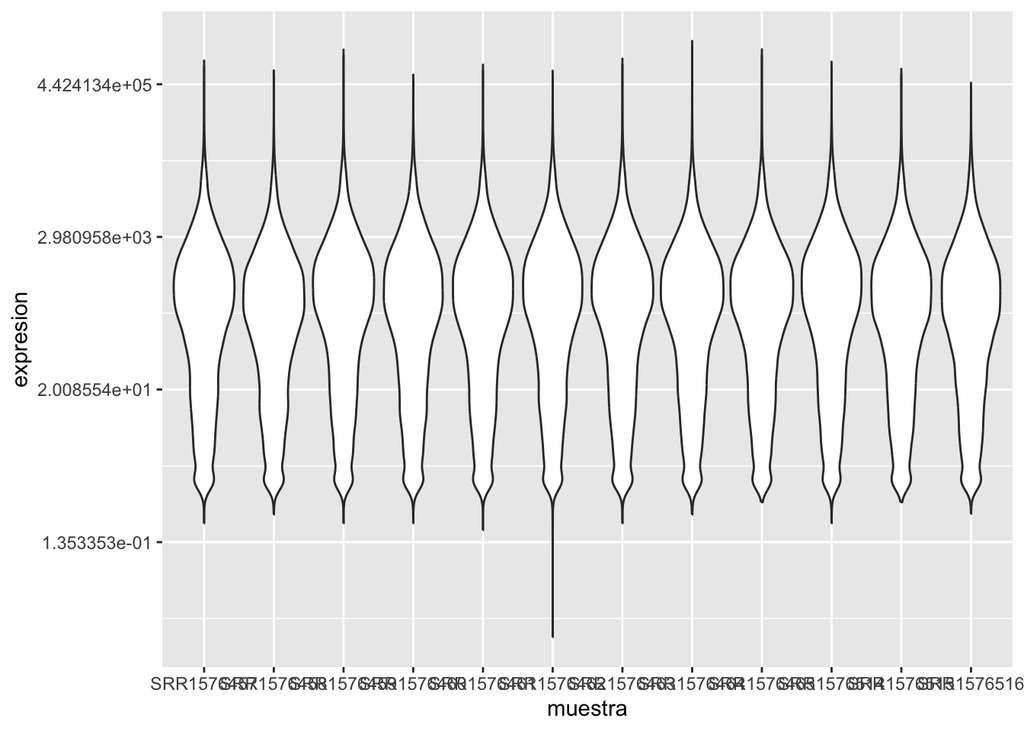

   ```r
   library(tidyr)
   library(ggplot2)
   genex_long <- pivot_longer(genex, 3:14, names_to = 'muestra', values_to = 'expresion')
   ggplot(data = genex_long, mapping = aes(x = muestra, y = expresion)) + geom_violin() + scale_y_continuous(trans = 'log')
   ```

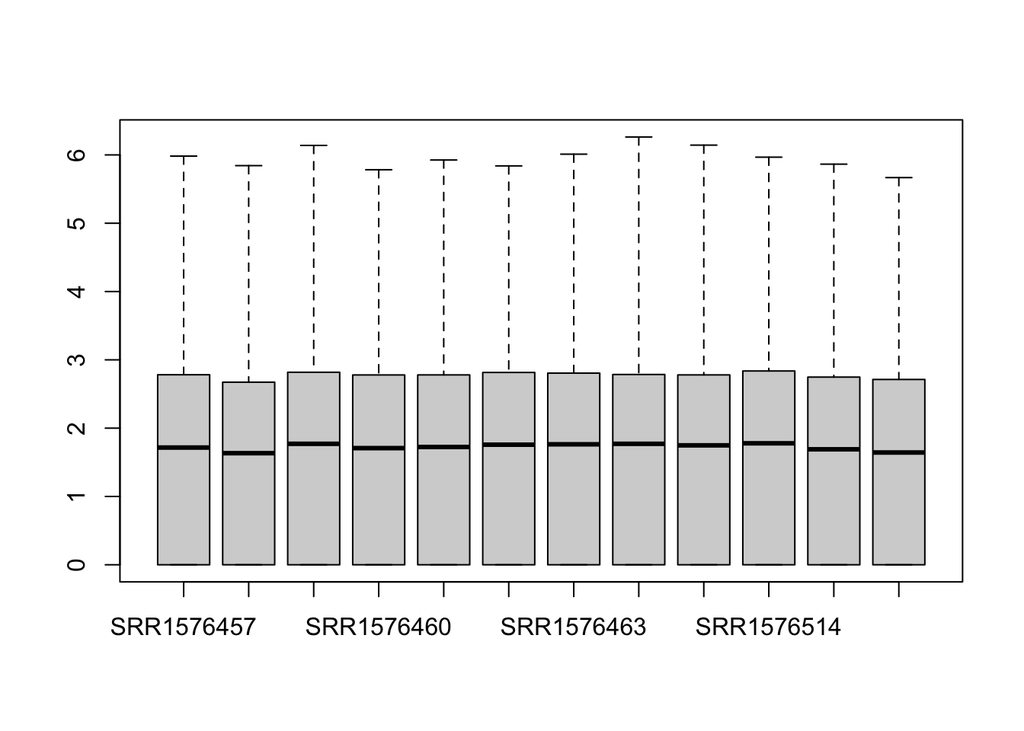

   ```r
   distribucion <- genex[, 3:ncol(genex)]
   boxplot(log10(distribucion + 1))
   ```

   Los recuentos tienen distribuciones muy similares, ya que la media y varianza de cada muestra se parecen bastante.
4. ¿Cuántos genes no se expresan en absoluto en ninguna de las muestras?

   ```r
   sum(rowSums(genex[, 3:ncol(genex)]) == 0)
   ```

   ```
   [1] 4722
   ```

   ```r
   f <- rowSums(genex[, 3:ncol(genex)]) > 0
   genex_f <- genex[f, ]
   ```

   Hay 4722 genes que no se expresan en ninguna muestra.

## Crear el objeto de clase `DESeqDataSet`

Para crear un objeto de `DESeqDataSet` necesitamos que las filas de `muestras` estén en el mismo orden que las columnas de `genex`. Además, la función `DESeqDataSetFromMatrix()` necesita que los recuentos sean una matriz, no un marco de datos, y que `muestras` haya factores.

```r
library(DESeq2)
all(names(genex)[3:14] == muestras$sample)
```

```
[1] TRUE
```

```r
# Pasamos la columna "sample" a nombres de fila:
row.names(muestras) <- muestras$sample
# Eliminamos la columna "sample":
muestras$sample <- NULL
# Y convertimos "population" y "temp" en factores:
muestras$population <- factor(muestras$population, levels = c('maine', 'panama'))
muestras$temp <- factor(muestras$temp, levels = c('low', 'high'))
muestras
```

```
           population temp    pop_temp
SRR1576457      maine  low   maine_low
SRR1576458      maine  low   maine_low
SRR1576459      maine  low   maine_low
SRR1576460      maine high  maine_high
SRR1576461      maine high  maine_high
SRR1576462      maine high  maine_high
SRR1576463     panama  low  panama_low
SRR1576464     panama  low  panama_low
SRR1576465     panama  low  panama_low
SRR1576514     panama high panama_high
SRR1576515     panama high panama_high
SRR1576516     panama high panama_high
```

```r
row.names(genex) <- genex$gene_name
genex$gene_name <- NULL
genex$gene_id   <- NULL
genex <- round(as.matrix(genex))
```

```r
dds1 <- DESeqDataSetFromMatrix(
   countData = genex,
   colData = muestras,
   design = ~ population + temp
)
dds1
```

```
class: DESeqDataSet
dim: 24254 12
metadata(1): version
assays(1): counts
rownames(24254): 7SLRNA:CR32864 a ... RR51477 Bari1{}RR51478
rowData names(0):
colnames(12): SRR1576457 SRR1576458 ... SRR1576515 SRR1576516
colData names(3): population temp pop_temp
```

**NotaNota**

Los objetos `DESeqDataSet` pueden contener información sobre las coordenadas cromosómicas de los genes o tránscritos, si se construyen a partir de otro tipo de datos.

## Pre-filtrado

Como hemos visto que una parte importante de los genes no se expresa en ninguna de las muestras podemos eliminarlos:

```r
keep <- rowSums(counts(dds1)) > 0
dds1 <- dds1[keep, ]
```

## Expresión diferencial

La función `DESeq()` produce un objeto de clase `DESeqDataSet` pero con resultados añadidos.

```r
dds1 <- DESeq(dds1)
# Estima los size factors y la dispersión, y aplica los tests estadísticos
```

```r
res <- results(dds1)
res
```

```
log2 fold change (MLE): temp high vs low
Wald test p-value: temp high vs low
DataFrame with 19508 rows and 6 columns
                baseMean log2FoldChange     lfcSE       stat      pvalue
               <numeric>      <numeric> <numeric>  <numeric>   <numeric>
7SLRNA:CR32864   346.333      0.5918974 1.3301901   0.444972 0.656339979
a                555.596     -0.2730041 0.0718487  -3.799708 0.000144866
abd-A            531.996     -0.0286785 0.0789218  -0.363379 0.716321800
Abd-B            634.760     -0.1083918 0.0771241  -1.405420 0.159896347
Abl             1654.842     -0.1328055 0.0746580  -1.778851 0.075264235
...                  ...            ...       ...        ...         ...
RR51007          4.90906      3.8596869  2.972471  1.2984773 1.94123e-01
RR51048         16.60710     -0.8973071  0.341603 -2.6267530 8.62039e-03
RR51093         36.93279      0.0660523  1.685323  0.0391927 9.68737e-01
RR51475        159.62678     -2.6058194  1.875172 -1.3896429 1.64637e-01
RR51477         70.83394      1.6927986  0.192437  8.7966372 1.40977e-18
                      padj
                 <numeric>
7SLRNA:CR32864  0.81170166
a               0.00154574
abd-A           0.85146309
Abd-B           0.33849233
Abl             0.20046251
...                    ...
RR51007        3.82417e-01
RR51048        4.01746e-02
RR51093        9.84464e-01
RR51475        3.44815e-01
RR51477        2.06431e-16
```

Si no le indicamos lo contrario, la función `results()` compara los resultados del último nivel y el de referencia del último factor en la tabla que describe las muestras. En este caso, está comparando los datos de `temp`, y los datos representan la relación entre los niveles de expresión de `high` con respecto a los de `low`.

**NotaEjercicio 3**

1. Mira la ayuda de `results()` y genera también la tabla de resultados para el contraste entre las dos regiones de procedencia de las moscas.

   ```r
   res2 <- results(dds1, contrast = c('population', 'panama', 'maine'))
   res2
   ```

   ```
   log2 fold change (MLE): population panama vs maine
   Wald test p-value: population panama vs maine
   DataFrame with 19508 rows and 6 columns
                   baseMean log2FoldChange     lfcSE      stat     pvalue
                  <numeric>      <numeric> <numeric> <numeric>  <numeric>
   7SLRNA:CR32864   346.333     -0.2116106 1.3301901 -0.159083  0.8736035
   a                555.596     -0.1114459 0.0718333 -1.551451  0.1207937
   abd-A            531.996      0.0460822 0.0789226  0.583890  0.5592940
   Abd-B            634.760     -0.0424386 0.0771227 -0.550274  0.5821316
   Abl             1654.842     -0.1477705 0.0746581 -1.979298  0.0477825
   ...                  ...            ...       ...       ...        ...
   RR51007          4.90906       2.118240  2.970241  0.713154 0.47575037
   RR51048         16.60710      -1.274560  0.344507 -3.699658 0.00021589
   RR51093         36.93279      -0.886468  1.685327 -0.525992 0.59889395
   RR51475        159.62678       0.121496  1.875169  0.064792 0.94833965
   RR51477         70.83394      -0.187567  0.188818 -0.993375 0.32052705
                        padj
                   <numeric>
   7SLRNA:CR32864   0.966480
   a                0.449953
   abd-A            0.838008
   Abd-B            0.850234
   Abl              0.288737
   ...                   ...
   RR51007        0.79163008
   RR51048        0.00812376
   RR51093        0.85672972
   RR51475        0.98600818
   RR51477        0.67811923
   ```

2. Usa `summary()` sobre los resultados para ver el número de genes diferencialmente expresados entre cada par de condiciones.

   ```r
   summary(res)
   ```

   ```
   out of 19508 with nonzero total read count
   adjusted p-value < 0.1
   LFC > 0 (up)       : 2418, 12%
   LFC < 0 (down)     : 2336, 12%
   outliers [1]       : 90, 0.46%
   low counts [2]     : 3018, 15%
   (mean count < 2)
   [1] see 'cooksCutoff' argument of ?results
   [2] see 'independentFiltering' argument of ?results
   ```

   ```r
   summary(res2)
   ```

   ```
   out of 19508 with nonzero total read count
   adjusted p-value < 0.1
   LFC > 0 (up)       : 623, 3.2%
   LFC < 0 (down)     : 634, 3.2%
   outliers [1]       : 90, 0.46%
   low counts [2]     : 3018, 15%
   (mean count < 2)
   [1] see 'cooksCutoff' argument of ?results
   [2] see 'independentFiltering' argument of ?results
   ```

   En total, hay 4754 genes expresados diferencialmente en las muestras de temperatura y 1257 genes en las de localización. Por tanto, podemos concluir que la temperatura afecta más que la localización a la expresión génica en estas muestras.
3. ¿Cuál es la tasa de falsos positivos (FDR)?

   Para calcular la tasa de falsos positivos dividimos el total de genes diferencialmente expresados según cada tratamiento (localización o temperatura) y los multiplicamos entre el umbral de p-valor seleccionado. :

   ```r
   # Para el caso de temperatura:
   FDR1 <- (2418 + 2336) * 0.1
   FDR1
   ```

   ```
   [1] 475.4
   ```

   ```r
   # Para el caso de localización:
   FDR2 <- (623 + 634) * 0.1
   FDR2
   ```

   ```
   [1] 125.7
   ```

## Gráficas

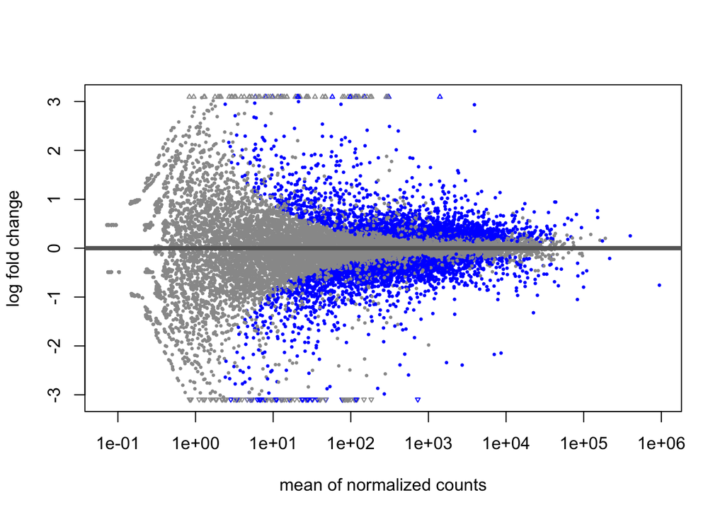

```r
plotMA(res)
```

Los genes con menor expresión (mayor varianza) producen resultados más ruidosos, pero con la función `lfcShrink` se pueden contraer las estimaciones de los efectos para reducir el ruido y hacer el resultado más realista:

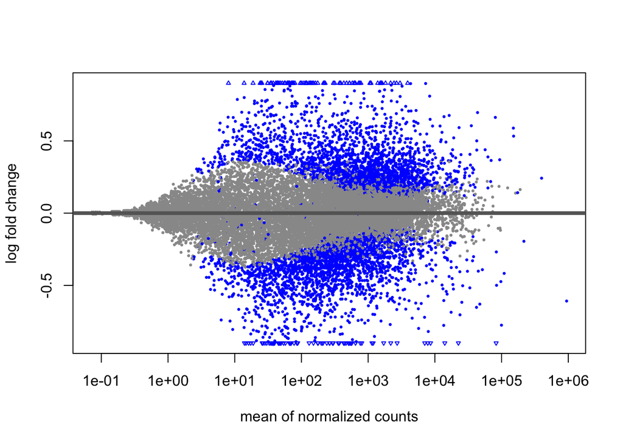

```r
resShrink <- lfcShrink(dds1, coef = 'temp_high_vs_low',
                       type = 'normal')
plotMA(resShrink)
```

**NotaEjercicio 4**

¿Sabrías hacer una gráfica volcán?

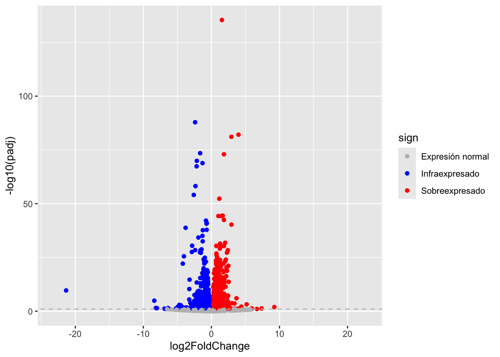

```r
res_volcan <- as.data.frame(res)
res_volcan$sign <- "Expresión normal"
res_volcan$sign[res_volcan$padj < 0.1 & res_volcan$log2FoldChange > 0] <- "Sobreexpresado"
res_volcan$sign[res_volcan$padj < 0.1 & res_volcan$log2FoldChange < 0] <- "Infraexpresado"

ggplot(data = res_volcan, mapping = aes(x = log2FoldChange, y = - log10(padj), color = sign)) +
  geom_point() +
  geom_abline(intercept = - log10(0.1), slope = 0, linetype = 2, color = "grey") +
  scale_color_manual(values = c("Expresión normal" = "grey", "Sobreexpresado" = "red", "Infraexpresado" = "blue"))
```

## Extraer datos transformados

No es necesario tener los datos normalizados para utilizar la función `DESeq()`, pero sí es recomendable hacerlo para representarlos gráficamente:

```r
dds2 <- vst(dds1)
NormCounts <- assay(dds2)
```

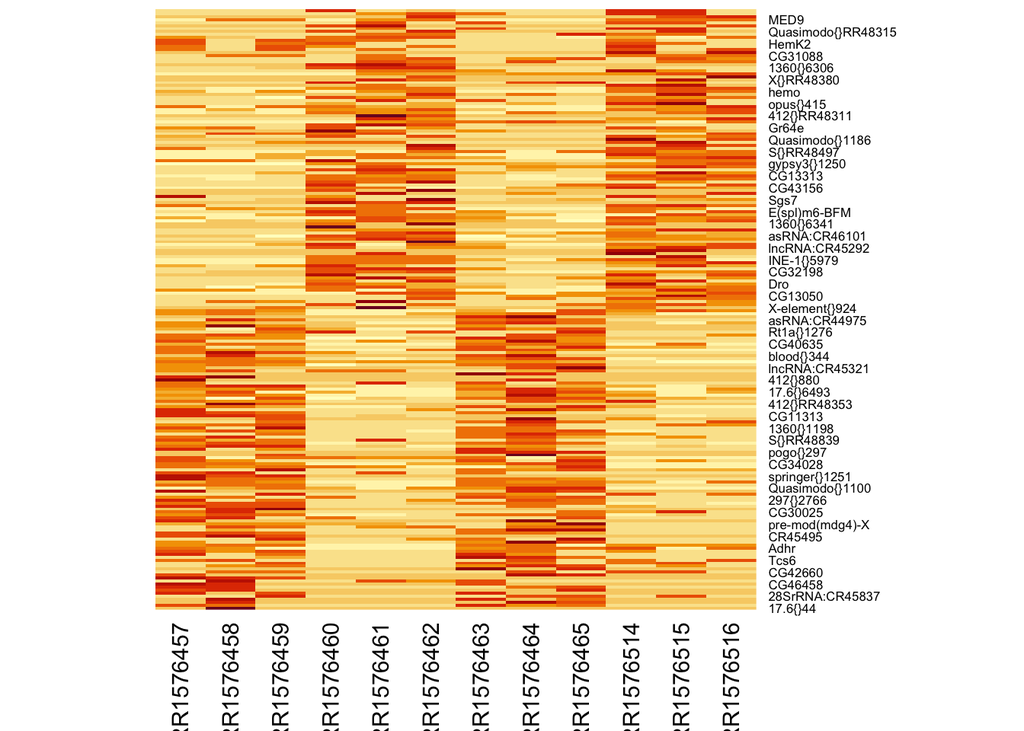

```r
res <- res[! is.na(res$pvalue), ]
res <- res[order(res$log2FoldChange),]
heatmap(NormCounts[c(head(row.names(res), 100),
                     tail(row.names(res), 100)), ],
        Rowv = NA, Colv = NA)
```

**NotaEjercicio 5**

¿Podrías explicar qué hace el bloque de código anterior?

En primer lugar se han eliminado los genes que no tienen ningún dato de p-valor (NA), y después se han ordenado en función del `log2FoldChange`, es decir, según su cambio de expresión. Después se ha creado el heatmap con los 100 primeros y los 100 últimos.

**NotaEjercicio 6**

En este enlace analizan exactamente los mismos datos con otro paquete de R: `limma`. Una de sus conclusiones es que se sobreexpresan más genes en temperatura baja que en temperatura alta. ¿Confirma tu análisis esta conclusión?

```r
head(res$log2FoldChange)
```

```
[1] -21.344666  -8.394351  -8.167196  -8.008740  -6.912812  -6.691802
```

```r
tail(res$log2FoldChange)
```

```
[1] 5.740400 5.869060 5.947814 6.682873 7.378101 9.240060
```

```
                   logFC  AveExpr         t      P.Value    adj.P.Val        B
Cpr92F          2.473527 6.201774  24.28881 1.306910e-13 1.739105e-09 21.29258
Vajk3           1.675184 4.029281  21.90298 6.069753e-13 3.524528e-09 19.66813
lncRNA:CR46017 -3.974938 1.044005 -21.50807 7.945880e-13 3.524528e-09 16.80878
CG7214          2.198970 7.945664  20.75054 1.349821e-12 4.490516e-09 19.14847
CG3739         -2.869172 6.514652 -20.49734 4.414988e-12 1.175005e-08 18.01975
Acp1            2.231834 7.638125  17.79441 2.089853e-11 3.997808e-08 16.54909
```

¿Cómo se comparan estos resultados con los tuyos?

```r
rownames(head(res, 10))
```

```
 [1] "17.6{}44"        "1360{}154"       "mdg3{}144"       "INE-1{}6041"
 [5] "28SrRNA:CR45837" "mei-217"         "rooA{}1584"      "blood{}218"
 [9] "CG46458"         "tal-1A"
```

```r
rownames(tail(res, 10))
```

```
 [1] "28SrRNA-Psi:CR45851" "HMS-Beagle{}116"     "Quasimodo{}RR48315"
 [4] "Obp50c"              "Stalker{}174"        "waw"
 [7] "MED9"                "CR45934"             "tal-AA"
[10] "pre-mod(mdg4)-U"
```

Los genes que más se sobreexpresan en nuestros datos no coinciden con los obtenidos con `limma`.